# Predictive Analysis of Car Prices: Identifying the Factors Influencing MSRP

MATH 40028/50028: Statistical Learning

May 05, 2024

## **Introduction**

#### **Car Features and MSRP Dataset**

The dataset includes information about the features of cars, along with their corresponding Manufacturer’s Suggested Retail Prices (MSRP). It contains over 11,000 entries and 16 variables, providing a comprehensive view of various aspects such as make, model, year, engine specifications, transmission type, and more. This dataset serves as a valuable resource for understanding the dynamics of automotive pricing and the factors that influence it.In today’s automotive market, buyers are often presented with a wide variety of vehicle options, ranging from compact city cars to rugged SUVs, each with its own unique set of features and specifications. However, one key factor that heavily influences a buyer’s decision-making process is the Manufacturer’s Suggested Retail Price (MSRP) of the vehicle.The MSRP provides potential buyers with an estimated price range for a particular car model. While the MSRP is typically determined by the manufacturer based on various factors such as production costs, market demand, and competitor pricing, predicting it accurately can be a complex task, especially given the multitude of features and attributes that contribute to a car’s value.

#### **Target Population, Sample Strategies, Potential Bias**

The target population for this analysis encompasses a diverse array of stakeholders within the automotive ecosystem, ranging from prospective car buyers to industry insiders seeking deeper insights into price trends.The method used for gathering the car’s characteristics and the MSRP approach have a big impact on how representative it is. For instance, the data can be biased in favor of the brands or models that the company sells if it originated from the inventory system of a car dealership. In the same way, data sourced from online listings could contain a higher percentage of cars from sellers who list their vehicles online, excluding cars that are sold through other channels.Accurately evaluating the dataset’s conclusions requires an understanding of how it was gathered.

The dataset may contain bias due to many variables. The dataset may be biased toward the dynamics of the luxury car industry if the data is mostly composed of automobiles from luxury brands due to a bias towards more expensive vehicles. Furthermore, since the features and costs of older models may vary greatly, a dataset that primarily consists of newer models may not fairly reflect the larger automobile industry.As we do not know from where the data is collected, and it is not mentioned on the website, we cannot accurately determine the sampling strategies and potential bias; we can only speculate.

#### **Prediction Problem**

The problem is to estimate the Manufacturer’s Suggested Retail Price (MSRP) of cars based on various inherent features of each vehicle. We aim to estimate the MSRP of cars based on their inherent features, such as engine horsepower, cylinders, transmission type, and vehicle size. By using machine learning techniques, we can develop predictive models that accurately forecast the MSRP for a given car. The goal is to provide valuable insights to stakeholders in the automotive industry to inform pricing strategies, market positioning, and consumer decision-making processes. By accurately predicting the MSRP of cars, we can help manufacturers and dealerships make informed decisions, and consumers can use this information to make informed purchasing decisions.

#### **Data Cleaning and Preprocessing**

After reading the dataset into R, I performed data preprocessing by first examining the dimensions and structure of the dataset, as it will provide insights for further procedure. After checking the structure of the data, the next step I implemented is finding the missing values, found that there are null values in the data and removed them for the data cleaniness and tp produce reliable results. Duplicate rows are found and removed by ensuring that each observation is uniques and contributes distinct information to the analysis. As ‘Market.category’ is not useful in predicting MSRP of cars, so variable ‘Market.category’ is removed form the dataset.

#### **Feature Engineering**

There are some variables that are categorical and need to be converted into factor variables for better analysis.The categorical variables such as ‘Make’, ‘Model’,‘Engine.Fuel.Type’, ‘Transmission.Type’, ‘Driven_Wheels’, ‘Vehicle.Size’, ‘Vehicle.Style are converted into factor variables as this feature transformation is necessary to encode as numerical values for further statistical modeling. Created a new variable called ’car_age’ which captures the age of each car based on its manufacturing year relative to a reference year(2017). The age of car is a crucial factor in determining its value and price trends. So, from this ‘car_age’ we get to know how old is the car and determine its price by its age like for old cars the market value decreases due to factors like wear, tear and usage of it.

#### **Data Splitting**

By using a random sample technique, the data was divided into training and test sets. In particular, 70% of the rows were chosen for the training set, while the remaining 30% were assigned to the test set. By using this technique, the prediction models are kept from overfitting and both sets are ensured to be representative of the entire dataset.The training set is used for model training and parameter estimation, while the test set is used as an independent dataset to assess the effectiveness and capacity for generalization of the learned models.

## **Statistical learning strategies and methods**

#### **EXPLORATORY DATA ANALYSIS**

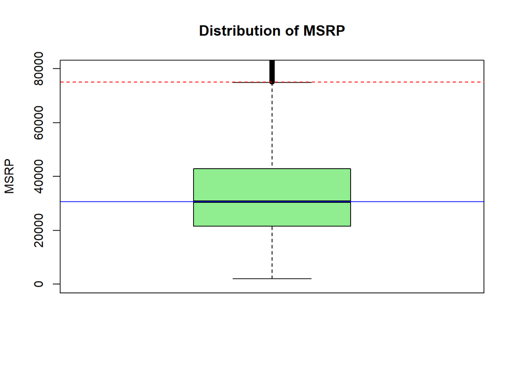

#### **Distribution Analysis of Numeric Features**

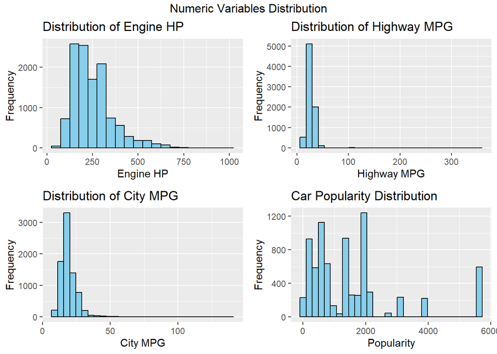

#### **Distribution of Engine Fuel Types**

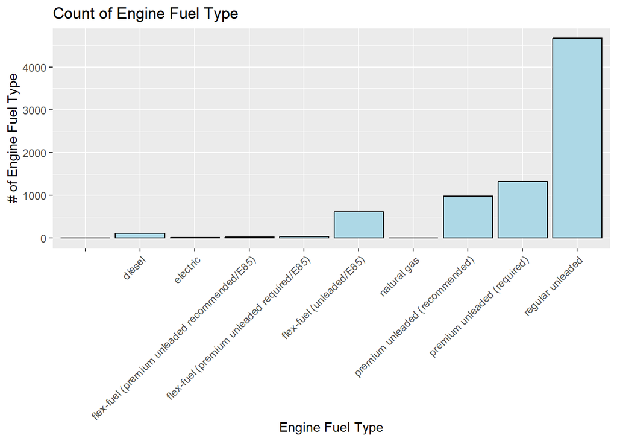

The bar graph shows the distribution of engine fuel types. There are different types of engine fuel like diesel, electric, flex-fuel (premium unleaded recommended/E85), flex-fuel (premium unleaded required/E85), flex-fuel (unleaded/E85), natural gas, premium unleaded (recommended), premium unleaded (required), and regular unleaded. The graph depicts that the most preferred or common fuel type is regular unleaded followed by premium unleaded(required). Electric and natural gas appear to be the least common fuel types.

#### **Distribution of Transmission Types**

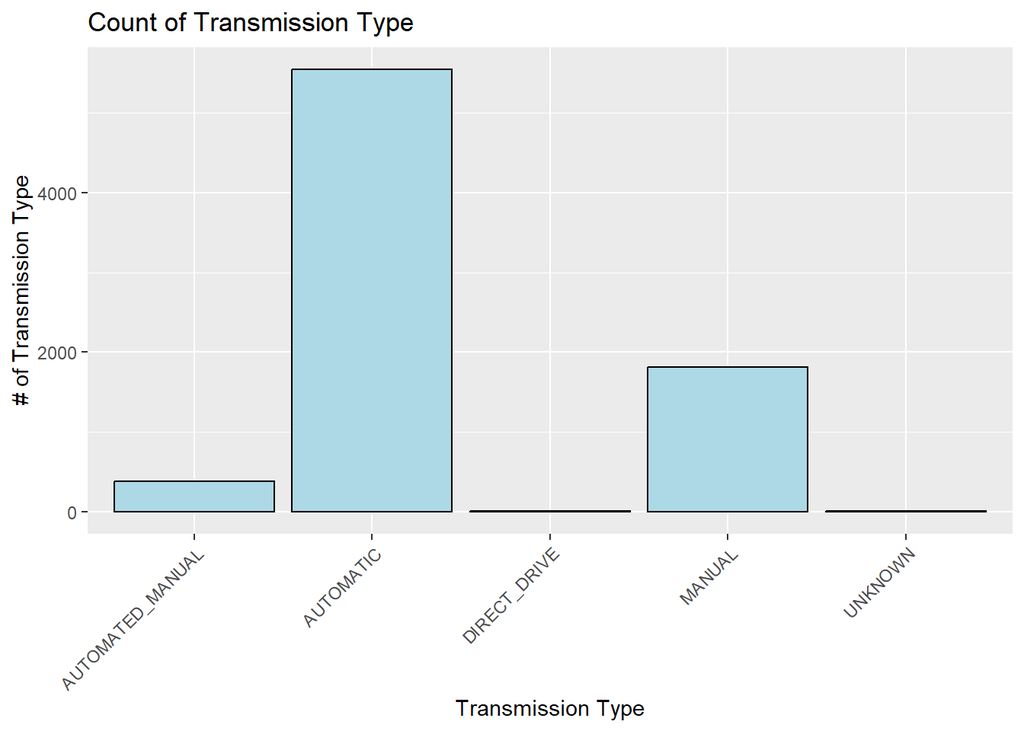

The bar plot shows the distribution of different Transmission types, which include automatic, manual, direct drive, and unknown.The graph depicts that automatic is the most common transmission type and then followed by manual. Direct drive and unknown have the least commong transmission types.

#### **Distribution of Engine Cylinders**

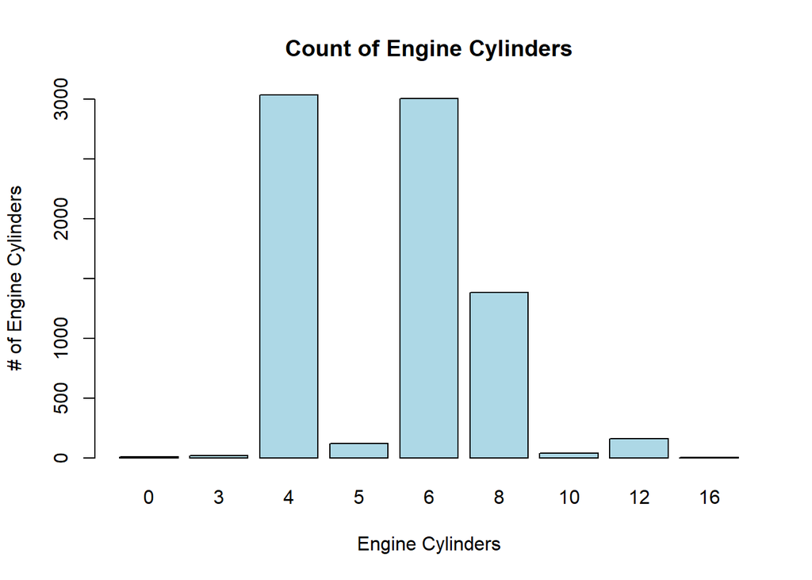

The bar plot shows the distribution of the number of engine cylinders. We observe that the most common engine setup appears to be the 4 and 6 cylinders. Engine with fewer than 4 cylinders and more than 8 appear to be less.

#### **Distribution of Driven Wheels**

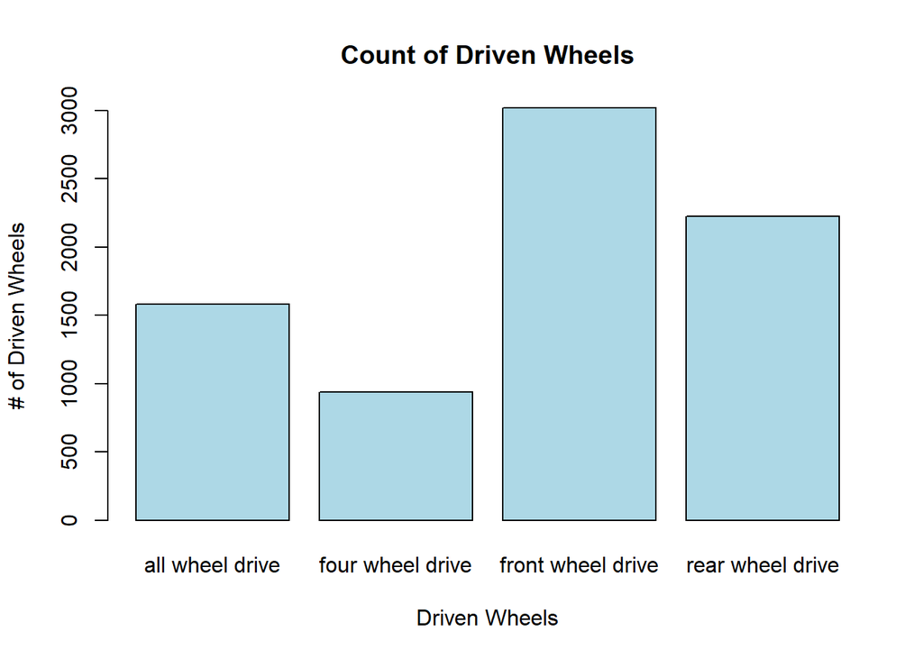

#### **Distribution of Number of Doors**

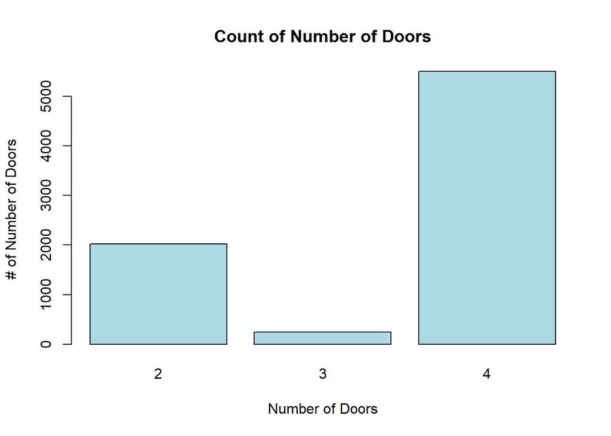

The bar plot shows the distribution of the number of doors in cars. The graph depicts that the cars with the most common number of doors is 4. There are also a significant numbers of w=cars with 2 doors. Cars with 3 doors appear to be less common.

#### **Relationship Between Engine Horsepower and MSRP**

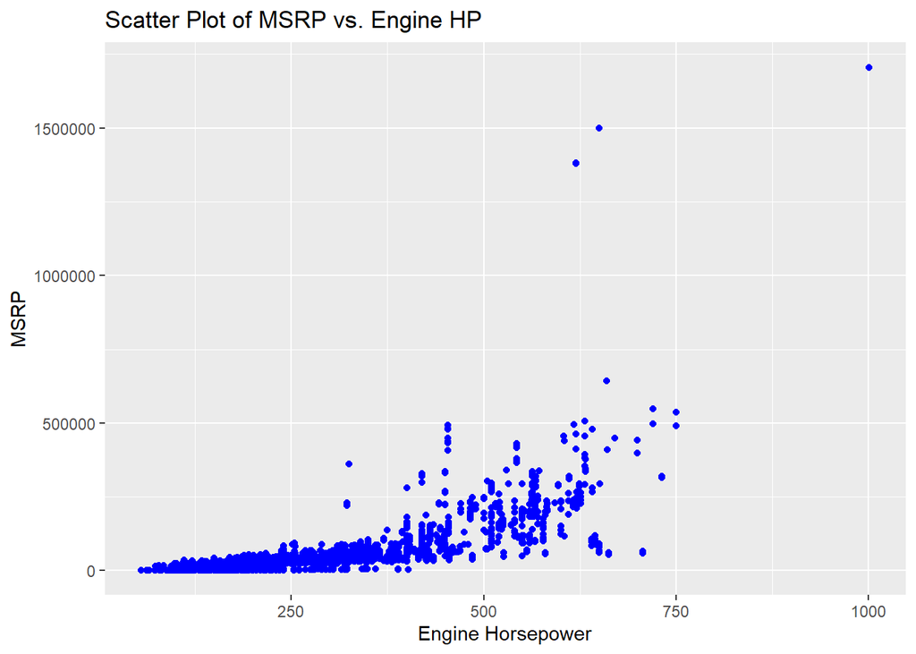

#### **MSRP Distribution Across Vehicle Sizes**

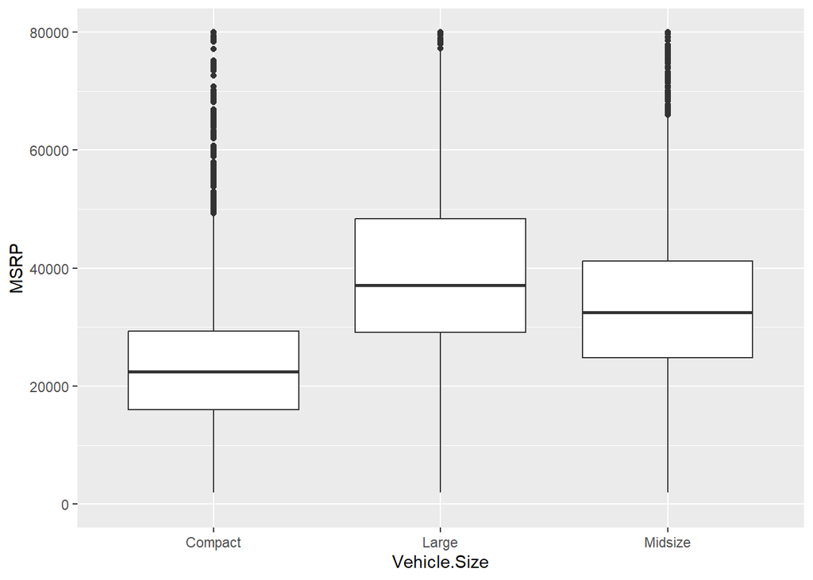

The boxplot shows the distribution of MSRP(Manufacturer’s Suggested Retail Price) across different vehicle sizes. We observe that Compact cars appear to have the lowest median MSRP. Large cars appear to have wide range of MSRPs, based on the boxplot followed by midsize cars.

#### **Correlation Analysis of Car Features and MSRP**

```
##              Engine.HP highway.MPG   city.mpg       MSRP
## Engine.HP    1.0000000  -0.4237203 -0.4747078  0.6589946
## highway.MPG -0.4237203   1.0000000  0.8428330 -0.2077737
## city.mpg    -0.4747078   0.8428330  1.0000000 -0.2326777
## MSRP         0.6589946  -0.2077737 -0.2326777  1.0000000
```

The relationship between Engine HP and MSRP is moderately positive. This suggests that as engine hp increases, the car’s price also increases. The relationship between highway MPG and MSRP is weakly negative, suggesting that higher priced cars tends to have slightly lower highway miles per gallon. The relationship between city MPG and MSRP is also weakly negative, suggesting that high priced cars have slightly lower city miles per gallon.

### **Pairwise Correlation Analysis of Numerical Variables**

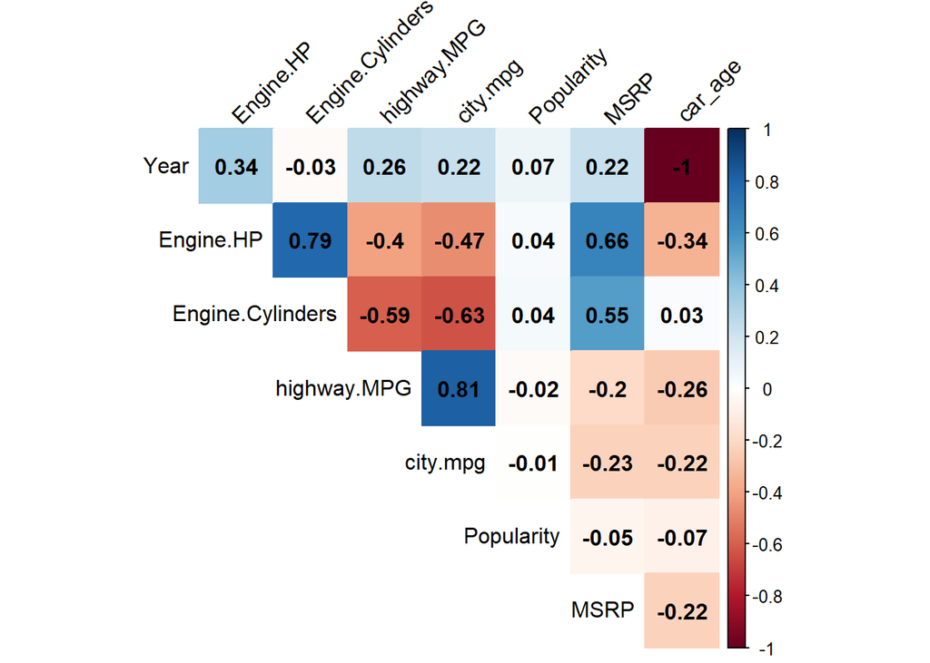

#### **ANOVA**

```
## ANOVA for Make :
##                       Df    Sum Sq   Mean Sq F value Pr(>F)
## as.factor(get(var))   45 1.970e+13 4.378e+11   439.8 <2e-16 ***
## Residuals           7720 7.684e+12 9.953e+08
## ---
## Signif. codes:  0 '***' 0.001 '**' 0.01 '*' 0.05 '.' 0.1 ' ' 1
##
## ANOVA for Engine.Fuel.Type :
##                       Df   Sum Sq   Mean Sq F value Pr(>F)
## as.factor(get(var))    9 6.98e+12 7.756e+11   294.8 <2e-16 ***
## Residuals           7756 2.04e+13 2.631e+09
## ---
## Signif. codes:  0 '***' 0.001 '**' 0.01 '*' 0.05 '.' 0.1 ' ' 1
##
## ANOVA for Transmission.Type :
##                       Df    Sum Sq   Mean Sq F value Pr(>F)
## as.factor(get(var))    4 1.826e+12 4.565e+11   138.6 <2e-16 ***
## Residuals           7761 2.556e+13 3.293e+09
## ---
## Signif. codes:  0 '***' 0.001 '**' 0.01 '*' 0.05 '.' 0.1 ' ' 1
##
## ANOVA for Driven_Wheels :
##                       Df    Sum Sq   Mean Sq F value Pr(>F)
## as.factor(get(var))    3 1.963e+12 6.543e+11   199.8 <2e-16 ***
## Residuals           7762 2.542e+13 3.275e+09
## ---
## Signif. codes:  0 '***' 0.001 '**' 0.01 '*' 0.05 '.' 0.1 ' ' 1
##
## ANOVA for Vehicle.Size :
##                       Df    Sum Sq   Mean Sq F value Pr(>F)
## as.factor(get(var))    2 4.614e+11 2.307e+11   66.52 <2e-16 ***
## Residuals           7763 2.692e+13 3.468e+09
## ---
## Signif. codes:  0 '***' 0.001 '**' 0.01 '*' 0.05 '.' 0.1 ' ' 1
##
## ANOVA for Vehicle.Style :
##                       Df    Sum Sq   Mean Sq F value Pr(>F)
## as.factor(get(var))   15 3.102e+12 2.068e+11      66 <2e-16 ***
## Residuals           7750 2.428e+13 3.133e+09
## ---
## Signif. codes:  0 '***' 0.001 '**' 0.01 '*' 0.05 '.' 0.1 ' ' 1
```

For each categorical variable, the ANOVA test evaluates whether there are significant differences in the mean MSRP across the levels of that variable.In the results, the Pr(>F) values are all very close to 0. This suggests that there are significant differences in MSRP across the levels of each categorical variable. The *** next to each categorical variable indicates that the p-value is highly significant (less than 0.001), providing strong evidence against the null hypothesis.Therefore, we can say that there are significant differences in MSRP across the levels of each categorical variable: Make, Engine.Fuel.Type, Transmission.Type, Driven_Wheels, Vehicle.Size, and Vehicle.Style. The ANOVA result for the ‘Make’ variable shows a highly significant p-value (< 2e-16), indicating that the mean MSRP values differ significantly across different car makes. This suggests that the car manufacturer is an important factor influencing the MSRP. The ANOVA result for ‘Engine.Fuel.Type’ also has a highly significant p-value (< 2e-16), implying that the mean MSRP values vary significantly based on the type of engine fuel (e.g., gasoline, diesel, electric). The ANOVA result for ‘Transmission.Type’ is significant, indicating that the mean MSRP differs across different types of transmissions (e.g., automatic, manual). The ANOVA result for ‘Driven_Wheels’ is significant, suggesting that the mean MSRP values vary based on the type of driven wheels (e.g., front-wheel drive, rear-wheel drive, all-wheel drive). The ANOVA result for ‘Vehicle.Size’ is significant, implying that the mean MSRP differs across different vehicle sizes (e.g., compact, midsize, large). The ANOVA result for ‘Vehicle.Style’ is significant, indicating that the mean MSRP values vary based on the style of the vehicle (e.g., sedan, coupe, hatchback).

## **STATISTICAL LEARNING METHODS**

For Car features and MSRP data analysis, I have used three different statistical learning methods to model the relationship between various car features and the Manufacturer’s Suggested Retail Price(MSRP) that are Random Forest, Decision Tree, and Gradient Boosting. Each of these methods have their own strengths and applicability to the prediction problem.

#### **Random Forest**

By using several decision trees and combining their predictions, Random Forest is an ensemble learning technique that improves accuracy and robustness. It is well-suited for handling complex datasets. For this prediction task, Random Forest is a good choice since it is less susceptible of the impact of outliers or noisy data points. Random Forest is useful for predicting car prices(MSRP) as it can capture complex relationships between car variables including Make, Model, and its engine features and more makes it effective for estimating car costs(MSRP).

#### **Decision Tree**

Decision tree is a model that works for both classification and regression problems, which are simple to understand and intuitive. Decision Trees are capable of capturing nonlinear relationships, handling both numerical and categorical data, and it requires little data preparation. Decision Trees is useful as it understands the connections between characteristics and MSRP and also can determine which elements most significantly affect since they are comparatively simple to comprehend.

#### **Gradient boosting**

Gradient boosting machines are effective are a type of ensemble learning method that combines multiple weak learners to improve predictive accuracy. It can also complex non-linear relationships between the predictors and the target variable(MSRP), fitting it for the variables complex interactions. Gradient boosting can be useful to make accurate predictions about car pricing.

## **Predictive analysis and results**

#### Random Forest

```
## Ranger result
##
## Call:
##  ranger(train_target ~ ., data = train_predictors, num.trees = 500)
##
## Type:                             Regression
## Number of trees:                  500
## Sample size:                      7766
## Number of independent variables:  15
## Mtry:                             3
## Target node size:                 5
## Variable importance mode:         none
## Splitrule:                        variance
## OOB prediction error (MSE):       553327226
## R squared (OOB):                  0.8431017
```

```
## [1] "RMSE: 18293.913062968"
```

```
## [1] "MAE: 4055.39377198584"
```

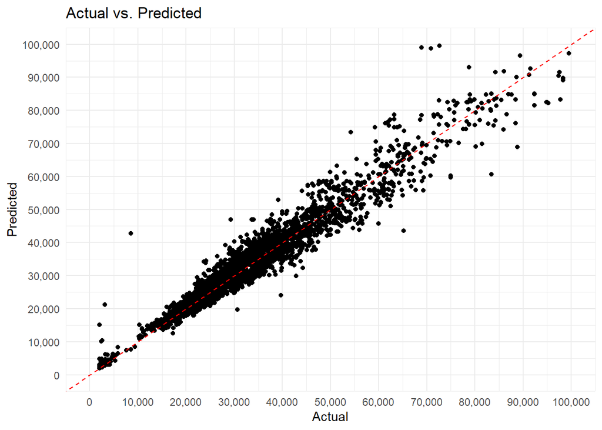

#### Decision tree

```
## [1] "RMSE: 27115.6704484809"
```

```
## [1] "R-squared: 0.838797153746599"
```

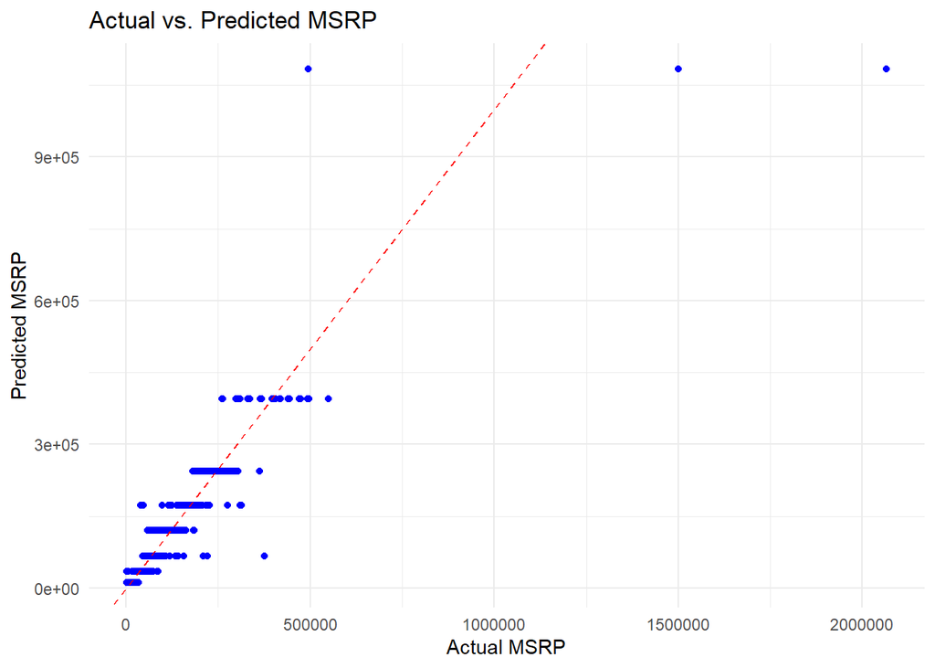

Using Decision Tree to predict the Manufacturer’s Suggested Retail Price (MSRP) of cars based on the other features. So it is observed that an An average difference between the expected and actual MSRP values is indicated by the root mean squared error (RMSE), which is around 27,115.67. Furthermore, the R-squared value of around 0.839 shows that the predictor variables in the model can account for 83.9% of the variation in MSRP.Overall, the decision tree model provides insightful information about the correlations between the predictor variables and MSRP, which makes it a helpful tool for comprehending the price dynamics of cars.

#### Gradient boosting

```
## [1] "RMSE: 36466.7706985751"
```

```
## [1] "R-squared: 0.704966877336109"
```

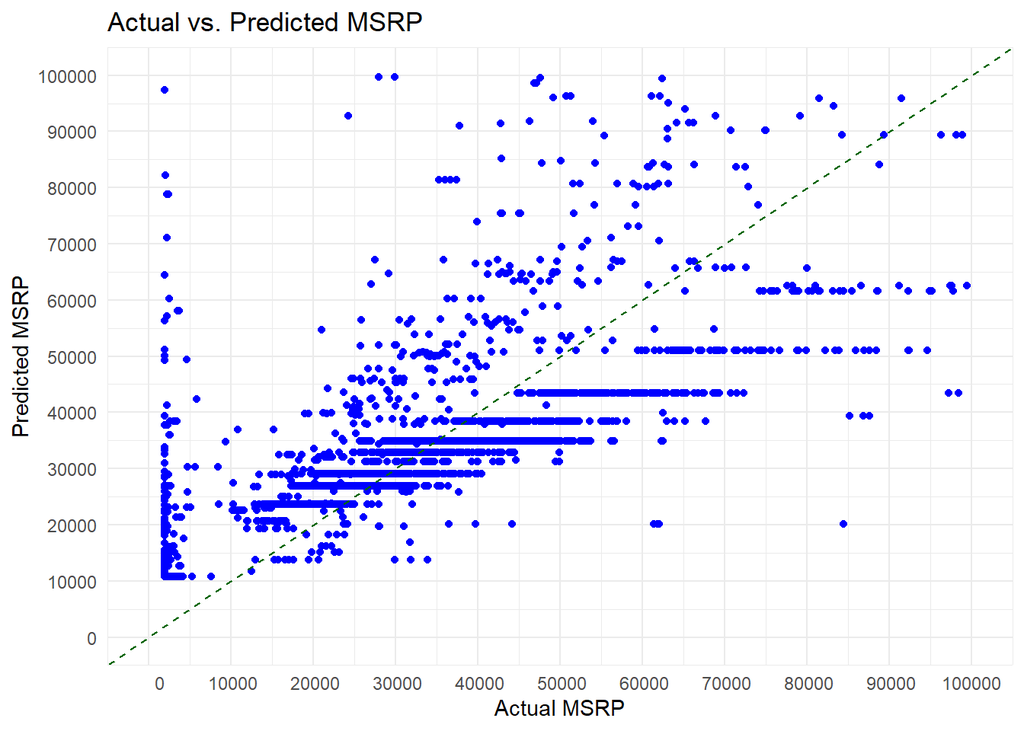

Using Gradient boosting for predicting the Manufacturer’s Suggested Retail Price (MSRP) of cars based on the other features.The model shows some degree of disparity between projected and real MSRP values, with a root mean squared error (RMSE) of around 36,466.77. Furthermore, the model’s predictor variables account for around 70.5% of the variance in MSRP, according to the R-squared value of roughly 0.705. Overall, the gradient boosting model is a useful tool for analyzing the price trends, since it provides insightful information about the correlations between the predictor variables and MSRP.

#### **Bootstrapping the Models**

#### Random forest

```
## [1] "Average RMSE across bootstrap samples: 22354.8533828291"
```

```
## [1] "Standard deviation of RMSE across bootstrap samples: 8052.05996640521"
```

```
## [1] "Average MAE across bootstrap samples: 4514.4781883893"
```

```
## [1] "Standard deviation of MAE across bootstrap samples: 246.298079121966"
```

```
## [1] "Average R-squared across bootstrap samples: 0.873967669998559"
```

```
## [1] "Standard deviation of R-squared across bootstrap samples: 0.0902385721417996"
```

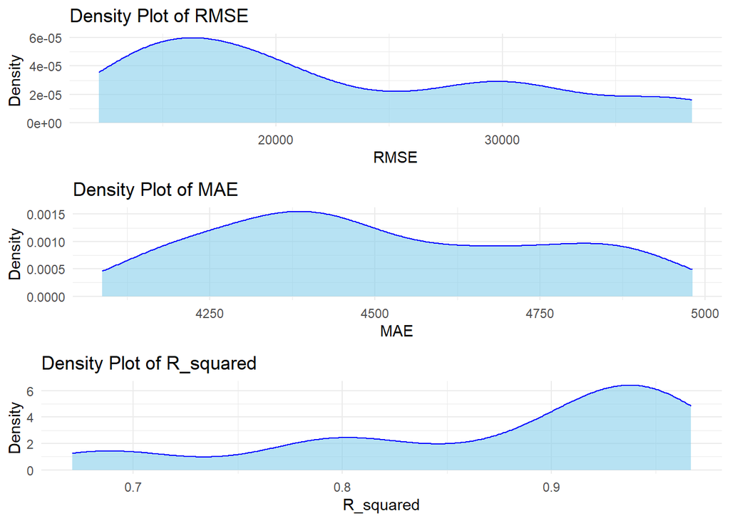

#### Decision tree

```
## [1] "Average RMSE across bootstrap samples: 22112.0232358889"
```

```
## [1] "Standard deviation of RMSE across bootstrap samples: 7270.45331638744"
```

```
## [1] "Average R-squared across bootstrap samples: 0.886719253827158"
```

```
## [1] "Standard deviation of R-squared across bootstrap samples: 0.0804075939178637"
```

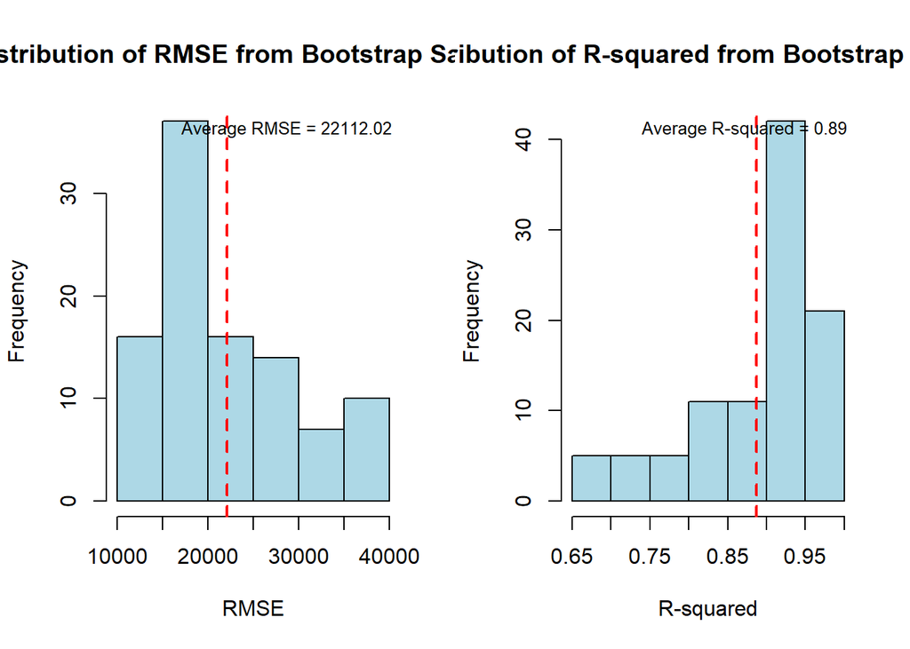

#### Gradient boosting

```
## [1] "Average RMSE across bootstrap samples: 43240.9933802132"
```

```
## [1] "Standard deviation of RMSE across bootstrap samples: 7374.74718280748"
```

```
## [1] "Average R-squared across bootstrap samples: 0.58200195267505"
```

```
## [1] "Standard deviation of R-squared across bootstrap samples: 0.142494376643549"
```

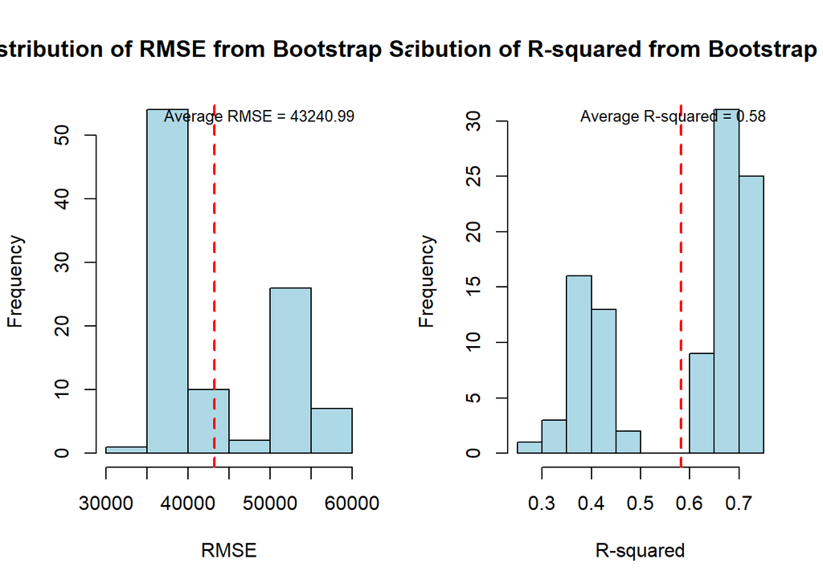

## **CONCLUSION**

#### **Scope and Generalizability**

The scope of the predictive analysis conducted on car features and MSRP dataset has a widespread impact on various stakeholders within the automotive industry. These stakeholders include manufacturers, dealerships, and consumers. By accurately predicting the Manufacturer’s Suggested Retail Price (MSRP) of cars based on their inherent features like make, model, engine specifications, and transmission type, the analysis provides valuable insights for pricing strategies, market positioning, and consumer decision-making processes. The predictive models developed using machine learning techniques like Random Forest, Decision Tree, and Gradient Boosting offer a robust framework for estimating car prices and understanding the underlying factors influencing them. These models enable stakeholders to make informed decisions regarding production, marketing, and purchasing. Ultimately, this contributes to the efficiency and competitiveness of the automotive market.

The predictive models used in this analysis are designed to forecast the Manufacturer’s Suggested Retail Price (MSRP) of cars based on the provided dataset. The models have demonstrated reasonable performance in terms of generalizability, but it’s important to acknowledge certain limitations and considerations regarding the generalizability of the analysis. Firstly, the dataset used to train and evaluate the models may not be fully representative of the entire automotive market. It may be biased towards certain brands, models, or market segments, which could limit the models’ applicability in other contexts. Additionally, the dataset used for training and evaluation may not capture all of the factors that influence the MSRP of a car, such as market trends, economic conditions, or consumer preferences. Therefore, it’s crucial to validate and test the models on diverse datasets to ensure their robustness and applicability across a wider range of scenarios. This will help ensure that the models can accurately forecast the MSRP of cars in different contexts and for different brands and models. Moreover, it’s important to consider the potential sources of error and uncertainty in the models. For example, the models may be sensitive to outliers or missing data, which could impact their accuracy and reliability. To mitigate these risks, it’s important to use appropriate methods for data cleaning and preprocessing and to carefully evaluate the models’ performance on validation datasets. Overall, while the predictive models used in this analysis show promising results, it’s important to approach their application with caution and to consider the potential limitations and sources of uncertainty. By doing so, we can ensure that the models are robust and reliable and that they provide accurate forecasts that can be useful for a variety of applications in the automotive industry.

Additionally, the predictive study assumes that the correlations between MSRP and car features found in the data would be true throughout time and in various market scenarios. However, outside variables like shifts in consumer tastes, the state of the economy, and technical developments can influence automobile costs and partially refute the models’ predictions. Predictive models must thus be continuously updated and monitored to preserve their accuracy and relevance in the face of shifting market circumstances.

#### **Limitations and Possibilities**

To guarantee the validity and dependability of the results, despite the predictive analysis’s insightful results, several possible restrictions should be noted. To begin with, the quality and representativeness of the dataset may have an impact on the prediction’s accuracy. Model performance may be impacted by sample biases introduced by data obtained from certain sources, such as web listings or dealership inventories. Predictive models also only take into account the fundamental characteristics of cars, ignoring other variables that might affect car costs, such as market demand, the state of the economy, and regulatory changes. To improve the predicted accuracy and relevance of the models, additional variables and larger datasets may be included.Additionally, the selection of statistical learning techniques may impose specific restrictions. While decision trees, gradient boosting, and random forests are effective tools for modeling intricate connections, other approaches like neural networks or ensemble methods may be investigated to enhance prediction accuracy even further. Additionally, optimizing model efficiency and interpretability by feature selection strategies and hyperparameter tweaking might increase the predictive models’ usefulness in practical applications. In conclusion, even if the predictive analysis provides insightful information about the dynamics of auto pricing, it is crucial to recognize and resolve any potential constraints to guarantee the validity and relevance of the results. Future rounds of the research can improve forecast accuracy and offer even deeper insights into the complex dynamics driving automobile pricing in the automotive sector by continually improving techniques, adding external factors, and broadening the sources of datasets.